# Class_1_Introduction_Python_Solow

## 1. Introduction to Python and the Solow Model

##### **By: Daniel Ricardo Amaya Alba, M.S. in Political Science from Los Andes University and Master's Student in Economics at Javeriana University**

### Why do we want to use Python for macroeconomics?

There are at least three main reasons to use Python in this course:

1. **Python is free and open-source.** Unlike some other programming languages and statistical software, Python can be installed and used without purchasing a license. We can also use **Google Colab**, which allows us to run Python directly in a web browser without installing anything on our computer. This is especially useful if we do not have a powerful machine, since part of the computation can be performed using Google's cloud infrastructure.
2. **Python is widely used in the labor market.** It has become one of the most popular programming languages in economics, data science, machine learning, and quantitative research.
3. **Python helps us understand macroeconomic models computationally.** By translating equations into code step by step, we can better understand how macroeconomic models work, simulate them, visualize their dynamics, and solve models that may be difficult or impossible to solve analytically.

In this first session, we will learn some basic Python concepts while working with the **Solow growth model**. The objective is not only to learn Python syntax, but also to understand how economic equations can be translated into computational algorithms.

## 2. Basic Python Objects and Syntax

Before working with the Solow model, we need to understand a few basic Python concepts. Python works with different types of **objects**, and each object can store or represent different kinds of information.

### 2.1 Variables

A **variable** is a name that we use to store a value.

For example:

```python
alpha = 0.33
beta = 0.96
delta = 0.10
```

In the line above, we simply define `alpha`, `beta`, and `delta` as variables. These variables represent parameters in our macroeconomic models. As you should already know, $\alpha$ represents the capital share, $\beta$ the discount factor, and $\delta$ the depreciation rate.

As you can see, Python uses the `=` symbol to assign a value to a variable.

It is important to understand that the `=` symbol in Python is an **assignment operator**, not the equality sign that we use in mathematics.

### 2.2 Numbers

Python can work with different types of numbers

#### Integers

These are numbers without decimals

```python
periods = 100
workers = 70
```

#### Floats

Floats are numbers with decimals:

```python
alpha = 0.33
beta = 0.96
delta = 0.10
dos= 2
```

Most parameters in macroeconomic models will usually be stored as floats.

We can perform standard mathematical operations:

```python
2+3
```

```python
dos + dos
```

```python
2 - 3
```

```python
2 * 3
```

```python
2 / 3
```

```python
2 ** 3
```

The operators mean:

| Python | Mathematical meaning |
| --- | --- |
| `+` | Addition |
| `-` | Subtraction |
| `*` | Multiplication |
| `/` | Division |
| `**` | Power |

For example the production function

$$ Y= AK^{\alpha} L^{1-\alpha} $$

can be written in Python as follows:

```
Y = A * K**alpha * L**(1-alpha)
```

### 2.3 Strings

A **string** is an object that contains text.

```python
model = "Solow model"
College = "Javeriana University"
```

Strings are written between quotation marks.

They are useful for labels, messages, titles, and descriptions.

also we can use the `f""` known as the f-string operator which allows us to insert variables or Python expressions directly inside a string.

For example:

```python
print(College)
```

```
Javeriana University
```

```python
f"I am a {College} master student and I am learning the {model} in python. In my first model the capital share (α) is {alpha} "
```

```
'I am a Javeriana University master student and I am learning the Solow model in python. In my first model the capital share (α) is 0.33 '
```

### 2.4 Booleans

A **Boolean** can take only two values:

```
True
False
```

Booleans are useful when Python needs to evaluate whether a condition is true or false.

For example:

```
k > 0
```

Python will return either:

```
True
```

or:

```
False
```

This becomes particularly important when we use conditional statements and loops. Remember this because you are going to use it a lot.

```python
alpha > 0.5
```

```python
alpha > 0.2
```

### 2.5 Lists

A **list** stores several objects in a single object.

```
capital = [1, 2, 3, 4, 5]
```

We can access individual elements using their position:

```
capital[0]
```

returns:

```
1
```

An important detail is that Python starts counting from **zero**.

Therefore:

```
capital[0]  # first element
capital[1]  # second element
capital[2]  # third element
```

Lists are useful when we want to store several values, such as capital levels across different periods.

```python
capital = [1, 2, 3, 4, 5]
```

We can access individual elements using their position. Note that Python, unlike us, starts counting from `0`. In that sense, when you want to access the **first object**, you need to request object `0`.

```python
capital[0]
```

Lists are useful when we want to store several values, such as capital levels across different periods.

### 2.6 NumPy Arrays

For numerical economics, we will frequently use **NumPy arrays** instead of regular Python lists.

First, we import NumPy.

Please have in mind that Python itself contains many basic tools, but additional libraries provide specialized functions.

In this course, we will frequently use:

```
import numpy as np
import matplotlib.pyplot as plt
```

`NumPy` is mainly used for numerical calculations, vectors, matrices, and arrays.

`Matplotlib` is used to create graphs.

The expressions `np` and `plt` are simply shorter names that we assign to these libraries.

```
import numpy as np
```

Then we can create an array:

```
capital = np.array([1, 2, 3, 4, 5])
```

Arrays allow us to perform mathematical operations on many numbers at the same time.

For example:

```
capital**0.33
```

Python will raise every element of the array to the power `0.33`.

This is extremely useful when we evaluate economic functions over many possible values.

```python
import numpy as np
```

now we can create an array as follows:

```python
capital = np.array([1, 2, 3, 4, 5], dtype=float)
print(capital)
```

Also, we can — and we will — use the NumPy function `linspace()` extensively throughout this course.

The function `np.linspace()` allows us to create an array containing a specified number of **equally spaced values** between a starting point and an ending point.

Its general structure is:

```
np.linspace(start, stop, num)
```

where:

- `start` is the first value,
- `stop` is the last value,
- `num` is the number of equally spaced points that we want to generate.

For example:

```python
capital = np.linspace(0, 10, 5)
print(capital)
```

Arrays allow us to perform mathematical operations on many numbers at the same time. This is extremely useful when we evaluate economic functions over many possible values.

For example:

```python
capital*2
```

### 2.7 Functions

A **function** allows us to write a mathematical relationship once and use it many times.

For example, suppose we have the Solow production function per worker:

$$ y = A k^\alpha $$

We can write it as:

```
def production(k, A, alpha):
    y = A * k**alpha
    return y
```

The structure is:

```
def function_name(inputs):
    operations
    return result
```

We can then evaluate the function:

```
production(10, 1, 0.33)
```

```python
def production(k, A, alpha):
    y = A * k**alpha
    return y
production(10, 1, 0.33)
```

The arguments have an economic interpretation:

- `k`: capital per worker,
- `A`: productivity,
- `alpha`: capital share.

Functions will be one of the most important tools in this course because economic models are essentially systems of functions and equations.

### 2.8 Conditional Statements

Python can execute different instructions depending on whether a condition is satisfied.

For example:

```python
k = 10
if k > 0:
    print("Capital is positive")
```

We can include an alternative:

```python
k = -10
if k > 0:
    print("Capital is positive")
else:
    print("Capital is not positive")
```

Also we can create a chain of conditionals

```python
k = 10
s = 0.25

if k > 0 and s >= 0.20:

    print("Capital is positive and the saving rate is relatively high")

elif k > 0 and s < 0.20:

    print("Capital is positive and the saving rate is relatively low")

else:

    print("Capital is not positive")
```

You can play with the code above to better understand how to use conditionals. Later, conditional statements will help us impose economic restrictions such as positive consumption or feasible levels of capital.

### 2.9 Loops

A **loop** tells Python to repeat an operation.

For example:

```python
for t in range(5):
    print(t)
```

Loops are extremely important in computational macroeconomics because many models evolve over time.

For example, we may want to compute:

$$ k_{t+1} $$

for many periods.

Conceptually, a loop allows us to tell Python:

> Start with an initial value of capital, apply the law of motion, obtain next period's capital, and repeat the process.

### 2.10 Numerical Precision and Tolerance

When we solve mathematical problems by hand, we usually work as if numbers were represented exactly.

For example,

$$ 0.1 + 0.2 = 0.3. $$

However, computers store numbers using a finite amount of memory. As a result, many decimal numbers cannot be represented exactly.

This issue is known as **floating-point precision**.

```python
0.1 + 0.2
```

[output not shown]

This does not mean that Python is doing the mathematics incorrectly. The difference appears because computers represent numbers internally using a finite binary representation. In most cases, this difference is extremely small. However, it becomes important when we compare numerical results or when we design algorithms that must determine whether a solution has converged.

```python
(0.1 + 0.2) == 0.3
```

For this reason, in numerical computation we often avoid asking whether two floating-point numbers are exactly equal.

Instead of requiring exact equality, we define a small number called a tolerance. For example,

$$\varepsilon = 10^{-8}$$

The idea is simple, two numerical values will be considered sufficiently close if the absolute difference between them is smaller than our tolerance.

$$|x-y| < \varepsilon$$

Lets define de tolerance in the code:

```python
tol=1e-10
abs((0.1 + 0.2) - 0.3) < tol
```

# 3. From the Solow Model to Python

Now that we know the basic Python tools that we need, we can use them to simulate our first macroeconomic model.

You already know the theory of the Solow growth model. Therefore, our objective here is not to derive the model again, but to understand how we can translate its equations into **computational instructions**.

For simplicity, suppose that there is no population growth and no technological growth.

The production function per worker is:

$$ y_t = A k_t^\alpha $$

A constant fraction $s$ of output is saved:

$$ i_t = s y_t $$

and capital depreciates at rate $\delta$.

Therefore, the law of motion of capital is:

$$ k_{t+1} = s A k_t^\alpha + (1-\delta)k_t $$

This equation is particularly useful computationally because it tells us exactly how to obtain tomorrow's capital once we know today's capital.

In other words:

$$ k_t \longrightarrow k_{t+1} $$

This is precisely the type of operation that a computer can repeat using a loop.

## 3.1 Calibrating the Model

Before solving the model, we need to assign numerical values to its parameters.

In computational economics, this step is usually called **calibration**.

```python
A = 1.0
alpha = 0.33
s = 0.25
delta = 0.10

k0 = 0.5
T = 250
```

Here:

- `A` represents productivity,
- `alpha` represents the capital share,
- `s` represents the saving rate,
- `delta` represents the depreciation rate,
- `k0` represents the initial level of capital,
- and `T` is the number of periods that we want to simulate.

Notice something important, we do not need a discount factor $\beta$ in the Solow model.

Why?

Because households are not solving an intertemporal optimization problem. The saving rate $s$ is given exogenously.

This will change when we move from the Solow model to the Ramsey model, you will see it with Andre, don't worry.

## 3.2 Defining the Production Function

We already learned how to define functions in Python.

The production function:

$$ y = Ak^\alpha $$

can be written as:

```python
def production(k, A, alpha):

    y = A * k**alpha

    return y
```

We can test the function for a particular level of capital.

```python
production(10, A, alpha)
```

```
2.137962089502232
```

The arguments of the function have a direct economic interpretation:

- `k` is capital per worker,
- `A` is productivity,
- `alpha` is the capital share.

An important advantage of writing the production function in this way is that we can use the same function many times without rewriting the equation.

Later, we will also see that the same function can receive either a single number or an entire NumPy array.

# 4. Simulating the Solow Model

The law of motion of capital is:

$$ k_{t+1} = sA k_t^\alpha + (1-\delta)k_t $$

Suppose initially that:

$$ k_0 = 0.5 $$

We first create a list containing our initial capital.

```python
k_path = [k0]
```

At this moment the list contains only:

$$ [k_0] $$

Therefore, `k_path[0]` represents:

$$ k_0 $$

Now we want Python to calculate:

$$ k_1,k_2,k_3,\ldots,k_T $$

using the same law of motion repeatedly.

So we are going to use a `for` loop

```python
k_path = [k0]

for t in range(T):

    k_next = (
        s * production(k_path[t], A, alpha)
        + (1 - delta) * k_path[t]
    )

    k_path.append(k_next)


len(k_path)
```

```
251
```

Let's understand the algorithm.

In the first iteration:

```
t = 0
```

Therefore, Python reads:

```
k_path[t]
```

as:

```
k_path[0]
```

which is our initial capital $k_0$.

Python then calculates:

$$ k_1 = sAk_0^\alpha + (1-\delta)k_0 $$

The instruction:

```
k_path.append(k_next)
```

adds the newly calculated capital to the list.

Therefore, after the first iteration, our list contains:

$$ [k_0,k_1] $$

In the second iteration:

```
t = 1
```

and Python uses `k_path[1]`, which is $k_1$, to calculate:

$$ k_2 = sAk_1^\alpha + (1-\delta)k_1 $$

The computer repeats exactly the same operation until we obtain:

$$ k_0,k_1,k_2,\ldots,k_T $$

Therefore, a `for` loop can be interpreted economically as the repeated application of a **difference equation**.

```python
print("Initial capital:", k_path[0])
print("Capital after 1 period:", k_path[1])
print("Capital after 250 periods:", k_path[-1])
```

```
Initial capital: 0.5
Capital after 1 period: 0.6488841209387297
Capital after 250 periods: 3.9259096150779365
```

# 5. Visualizing the Transition Dynamics

Looking only at numbers makes it difficult to understand the entire trajectory of the economy.

Graphs allow us to visualize:

$$ k_0,k_1,k_2,\ldots,k_T $$

and study how the economy evolves over time.

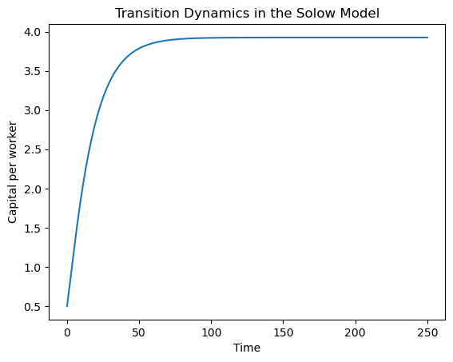

```python
import matplotlib.pyplot as plt

plt.plot(k_path)

plt.xlabel("Time")
plt.ylabel("Capital per worker")
plt.title("Transition Dynamics in the Solow Model")

plt.show()
```

The horizontal axis represents time:

$$ t = 0,1,2,\ldots,T $$

while the vertical axis represents capital per worker:

$$ k_t $$

If the initial level of capital is below the steady state, we should observe capital increasing over time and gradually approaching a constant value.

If the initial capital is above the steady state, we should observe capital decreasing toward that same value.

This gives us our first computational representation of **convergence**.

## Activity — Changing the Saving Rate

Run the simulation using:

$$ s = 0.25 $$

Then change the saving rate to:

$$ s = 0.35 $$

and run the model again.

This is a simple example of using computational methods to perform **comparative statics and comparative dynamics**.

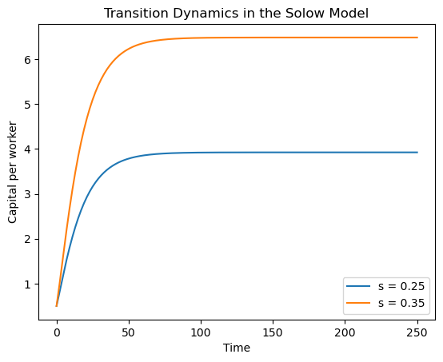

```python
s1 = 0.25
s2 = 0.35

#  s = 0.25
k_path_1 = [k0]

for t in range(T):

    k_next = (
        s1 * production(k_path_1[t], A, alpha)
        + (1 - delta) * k_path_1[t]
    )

    k_path_1.append(k_next)


#  s = 0.35
k_path_2 = [k0]

for t in range(T):

    k_next = (
        s2 * production(k_path_2[t], A, alpha)
        + (1 - delta) * k_path_2[t]
    )

    k_path_2.append(k_next)


# Overlaid plot
plt.plot(k_path_1, label="s = 0.25")
plt.plot(k_path_2, label="s = 0.35")

plt.xlabel("Time")
plt.ylabel("Capital per worker")
plt.title("Transition Dynamics in the Solow Model")
plt.legend()

plt.show()
```

# 6. The Steady State

You already know that the steady state is a situation in which capital per worker does not change.

Therefore:

$$ k_{t+1}=k_t=k^* $$

Using the Solow law of motion:

$$ k^* = sA(k^*)^\alpha + (1-\delta)k^* $$

Subtracting $(1-\delta)k^*$ from both sides:

$$ k^*-(1-\delta)k^* = sA(k^*)^\alpha $$

Therefore:

$$ \delta k^* = sA(k^*)^\alpha $$

Dividing by $(k^*)^\alpha$:

$$ \delta(k^*)^{1-\alpha} = sA $$

Therefore:

$$ (k^*)^{1-\alpha} = \frac{sA}{\delta} $$

Finally:

$$ \boxed{ k^* = \left( \frac{sA}{\delta} \right)^{\frac{1}{1-\alpha}} } $$

Because this model has an analytical solution, we can calculate the steady state directly in Python.

```python
s= 0.25

k_ss = (s * A / delta)**(1 / (1 - alpha))

print(k_ss)
```

```
3.9259097478746208
```

### Visualizing the Steady State

We now have a number, but a number on its own does not teach very much. Let us go back to the trajectory that we simulated in Section 4 and draw $k^*$ on top of it.

A new instruction: `plt.axhline(value)` draws a **horizontal line** across the whole figure. It is the natural way to mark a constant, such as a steady state.

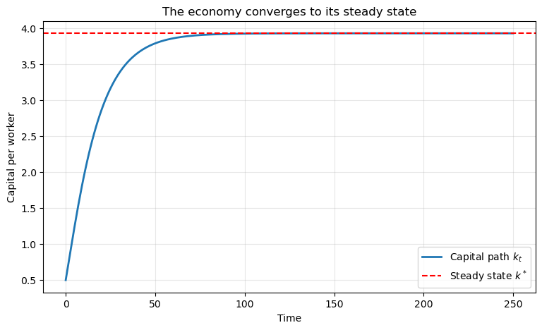

```python
plt.figure(figsize=(9, 5))

plt.plot(k_path, linewidth=2, label="Capital path $k_t$")
plt.axhline(k_ss, color="red", linestyle="--", label="Steady state $k^*$")

plt.xlabel("Time")
plt.ylabel("Capital per worker")
plt.title("The economy converges to its steady state")
plt.legend()
plt.grid(alpha=0.3)

plt.show()
```

This is convergence, seen directly.

The capital path rises quickly at first and then flattens onto the dashed line. It approaches $k^*$ but never crosses it. The reason is economic, not numerical: the production function is concave, so when capital is scarce its marginal product is high and each unit of investment adds a lot. As capital accumulates, the marginal product falls, and eventually the investment that the economy generates is only just enough to replace what depreciates. At that point capital stops changing.

Notice one subtle thing. After 250 periods the capital path matches $k^*$ to six decimal places, but it never *exactly* equals it: each period the economy closes a fixed fraction of the remaining distance, so the gap shrinks toward zero without ever becoming zero. Convergence here is **asymptotic**.

That is precisely why, in the next section, we will not be able to ask the computer whether $k_{t+1}$ equals $k_t$. We will have to ask whether they are close enough — which is the tolerance we introduced in Section 2.10, now doing real work.

## 6.1 Finding the Steady State Numerically

Until now, we have obtained the steady state using its analytical solution:

$$ k^* = \left( \frac{sA}{\delta} \right)^{\frac{1}{1-\alpha}} $$

However, many macroeconomic models do not have a closed-form solution.

Therefore, we also need to learn how to find a steady state **numerically**.

Remember that the steady state satisfies:

$$ k_{t+1}=k_t $$

Computationally, because of numerical precision, we will instead look for a value such that:

$$ |k_{t+1}-k_t|<\varepsilon $$

where $\varepsilon$ is our tolerance.

Instead of deciding in advance how many periods to simulate, we can tell Python:

> Continue iterating while capital is still changing by more than our tolerance.

For this purpose, we use a `while` loop.

```python
k_old = 0.5

tol = 1e-8
error = 1.0

iteration = 0
max_iter = 10000

while error > tol and iteration < max_iter:

    k_new = (
        s * production(k_old, A, alpha)
        + (1 - delta) * k_old
    )

    error = abs(k_new - k_old)

    k_old = k_new

    iteration = iteration + 1
```

Let's read the algorithm step by step.

First, we start from an initial guess:

$$ k^{(0)}=0.5 $$

At every iteration, Python applies the Solow law of motion:

$$ k^{(n+1)} = sA(k^{(n)})^\alpha + (1-\delta)k^{(n)} $$

Then, we calculate the difference between the new and old values:

$$ \text{error} = |k^{(n+1)}-k^{(n)}| $$

If:

$$ \text{error}>\varepsilon $$

Python continues iterating.

If:

$$ \text{error}<\varepsilon $$

we consider that the algorithm has converged.

Notice the difference between `for` and `while`:

- `for` repeats an operation a predetermined number of times.
- `while` repeats an operation until a condition is satisfied.

```python
print("Numerical steady state:", k_old)
print("Analytical steady state:", k_ss)
print("Number of iterations:", iteration)
print("Final convergence error:", error)
print("Difference:", abs(k_old - k_ss))
```

```
Numerical steady state: 3.9259096150779365
Analytical steady state: 3.9259097478746208
Number of iterations: 250
Final convergence error: 9.536310408009285e-09
Difference: 1.3279668431565028e-07
```

We should obtain:

$$ k^*_{\text{numerical}} \approx k^*_{\text{analytical}} $$

This illustrates one of the most important principles of computational economics:

> **Whenever we have an analytical solution, we should use it to validate our numerical algorithm.**

The computer can produce a number even when our code is wrong. Therefore, numerical results should be tested whenever possible against a case in which we already know the correct answer.

The structure of our algorithm is:

$$ \text{initial guess} \rightarrow \text{apply the law of motion} \rightarrow \text{calculate the error} \rightarrow \text{update} \rightarrow \text{repeat} $$

This is our first example of a **fixed-point algorithm**. Don't worry if you don't understand it, later I will explain it to you.

In the Solow model, we iterate a number:

$$ k $$

Later in the course, when we study dynamic programming, we will use a similar logic to iterate a function:

$$ V(k) $$

# 7. The Solow Diagram

We have now found the steady state three times: with a formula, with an algorithm, and as a horizontal line that the economy approaches. But we still have not seen **why** it sits exactly where it sits.

The Solow diagram answers that question, and it does so by changing what we put on the horizontal axis. Until now the horizontal axis was **time**. Now it will be **capital**.

The trick is to rewrite the law of motion. Starting from

$$ k_{t+1} = sAk_t^{\alpha} + (1-\delta)k_t $$

and subtracting $k_t$ from both sides:

$$ \underbrace{k_{t+1}-k_t}_{\text{change in capital}} = \underbrace{sAk_t^{\alpha}}_{\text{what we add}} - \underbrace{\delta k_t}_{\text{what we lose}} $$

Read that equation carefully, because the whole model is in it:

- Capital **grows** whenever investment $sAk^{\alpha}$ exceeds depreciation $\delta k$.
- Capital **falls** whenever depreciation exceeds investment.
- Capital is **constant** exactly where the two are equal.

So if we draw both objects as functions of $k$, the steady state is simply the point where the curve crosses the line.

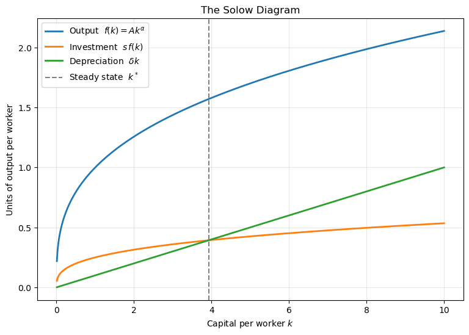

```python
import numpy as np
# A grid of capital values on which to evaluate the two curves
k_grid = np.linspace(0.01, 10, 500)

output       = production(k_grid, A, alpha)   # f(k)
investment   = s * output                     # s f(k)
depreciation = delta * k_grid                 # delta k

plt.figure(figsize=(9, 6))

plt.plot(k_grid, output,       linewidth=2, label=r"Output  $f(k) = Ak^{\alpha}$")
plt.plot(k_grid, investment,   linewidth=2, label=r"Investment  $s\,f(k)$")
plt.plot(k_grid, depreciation, linewidth=2, label=r"Depreciation  $\delta k$")

plt.axvline(k_ss, color="gray", linestyle="--", label=r"Steady state  $k^*$")

plt.xlabel("Capital per worker $k$")
plt.ylabel("Units of output per worker")
plt.title("The Solow Diagram")
plt.legend()
plt.grid(alpha=0.3)

plt.show()
```

Three things are worth reading off this figure.

**First, the shapes are economics, not decoration.** Output $f(k)$ is concave because capital has diminishing returns: the first machine transforms a workshop, the hundredth barely helps. Investment $s\,f(k)$ is that same curve scaled down by the saving rate, so it is concave too. Depreciation $\delta k$, on the other hand, is a **straight line**: we always lose the same fraction of whatever stock we have. A concave curve that starts steep and a straight line that starts flat must cross exactly once. That single crossing is why the steady state exists and why it is unique.

**Second, the vertical distance between $f(k)$ and $s\,f(k)$ is consumption.** Everything that is not saved is consumed. Later in the course, when households actually get to choose, this distance stops being a fixed proportion and becomes the object of a decision.

### Why does the economy move toward $k^*$?

The diagram does not only tell us where the steady state is. It tells us in which direction the economy travels from anywhere else.

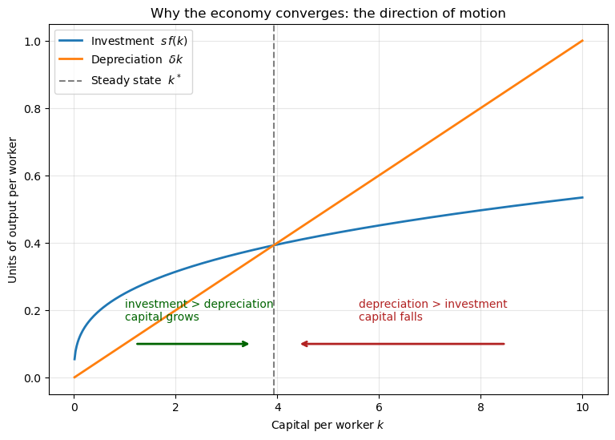

```python
k_grid = np.linspace(0.01, 10, 500)

plt.figure(figsize=(9, 6))

plt.plot(k_grid, s * production(k_grid, A, alpha), linewidth=2, label=r"Investment  $s\,f(k)$")
plt.plot(k_grid, delta * k_grid, linewidth=2, label=r"Depreciation  $\delta k$")
plt.axvline(k_ss, color="gray", linestyle="--", label=r"Steady state  $k^*$")

# plt.annotate writes text on the figure; arrowprops turns it into an arrow
plt.annotate("", xy=(3.5, 0.10), xytext=(1.2, 0.10),
             arrowprops=dict(arrowstyle="->", linewidth=2, color="darkgreen"))
plt.text(1.0, 0.17, "investment > depreciation\ncapital grows", color="darkgreen")

plt.annotate("", xy=(4.4, 0.10), xytext=(8.5, 0.10),
             arrowprops=dict(arrowstyle="->", linewidth=2, color="firebrick"))
plt.text(5.6, 0.17, "depreciation > investment\ncapital falls", color="firebrick")

plt.xlabel("Capital per worker $k$")
plt.ylabel("Units of output per worker")
plt.title("Why the economy converges: the direction of motion")
plt.legend(loc="upper left")
plt.grid(alpha=0.3)

plt.show()
```

To the **left** of $k^*$ the investment curve lies above the depreciation line, so the economy adds more capital than it loses and moves to the right. To the **right** of $k^*$ the depreciation line is above the investment curve, so the economy loses more than it adds and moves to the left.

Both arrows point toward the same place. This is what we mean when we say the steady state is **globally stable**: the economy converges to $k^*$ from any starting point. It is also, incidentally, the reason our `while` loop worked no matter what initial guess we gave it. Try changing `k_old = 0.5` to `k_old = 30` in Section 6.1 and running it again: it lands on exactly the same number.

### The diagram explains our earlier activity

Remember the exercise where we raised the saving rate from $s = 0.25$ to $s = 0.35$ and the capital path shifted upward. Now we can see exactly why.

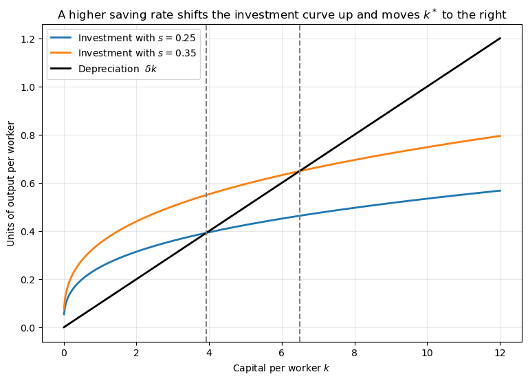

```
With s = 0.25:  k* = 3.926   y* = 1.570
With s = 0.35:  k* = 6.487   y* = 1.853

Capital rises by 65.2%
Output  rises by 18.0%
```

```python
k_grid = np.linspace(0.01, 12, 500)

k_ss_1 = (s1 * A / delta)**(1 / (1 - alpha))
k_ss_2 = (s2 * A / delta)**(1 / (1 - alpha))

plt.figure(figsize=(9, 6))

plt.plot(k_grid, s1 * production(k_grid, A, alpha), linewidth=2, label=r"Investment with $s = 0.25$")
plt.plot(k_grid, s2 * production(k_grid, A, alpha), linewidth=2, label=r"Investment with $s = 0.35$")
plt.plot(k_grid, delta * k_grid, linewidth=2, color="black", label=r"Depreciation  $\delta k$")

plt.axvline(k_ss_1, color="gray", linestyle="--")
plt.axvline(k_ss_2, color="gray", linestyle="--")

plt.xlabel("Capital per worker $k$")
plt.ylabel("Units of output per worker")
plt.title("A higher saving rate shifts the investment curve up and moves $k^*$ to the right")
plt.legend(loc="upper left")
plt.grid(alpha=0.3)

plt.show()

y_ss_1 = production(k_ss_1, A, alpha)
y_ss_2 = production(k_ss_2, A, alpha)

print(f"With s = {s1}:  k* = {k_ss_1:.3f}   y* = {y_ss_1:.3f}")
print(f"With s = {s2}:  k* = {k_ss_2:.3f}   y* = {y_ss_2:.3f}")
print()
print(f"Capital rises by {100*(k_ss_2/k_ss_1 - 1):.1f}%")
print(f"Output  rises by {100*(y_ss_2/y_ss_1 - 1):.1f}%")
```

A higher saving rate does not change depreciation, and it does not change the production function. It simply lifts the investment curve, so the crossing point slides to the right. That is the entire content of the comparative-statics exercise we ran earlier, in one picture.

But now look at the numbers printed under the figure, because they contain the single most important lesson of this model.

Raising the saving rate by 40% (from 0.25 to 0.35) raises steady-state **capital** by about 65%. That sounds like a lot. But steady-state **output** rises by only about 18%, and output is what people actually consume. The reason is the concavity we have been talking about all along: that extra capital is being added precisely where the production function has already flattened out, so each additional machine buys very little additional output.

This is why the Solow model, taken literally, has a hard time explaining why some countries are rich and others are poor. Saving more helps, but it runs into diminishing returns very quickly — a point we will confront directly with real data in this week's activity.

### Where this is going

Notice what the investment curve $s\,f(k)$ really is: it is a **decision rule**. It says how much this economy sets aside for tomorrow, for every level of capital it might have today. In the Solow model we simply assumed that rule was a constant fraction of output, and we drew it.

In the models that come next, nobody hands us that rule. Households choose it, weighing consumption today against consumption tomorrow, and the decision at every level of capital depends on what they plan to do at every other level. Our job will be to **find** that curve rather than assume it.

That is what the Bellman equation is for. And when we go looking for it, we will use the very same `while` loop we wrote in Section 6.1 — the difference being that what stops changing will no longer be a number, but an entire function.